# Lab 9 with solutions

Univariate Statistics with R

Today’s lab is primarily focused on extending our knowledge/experience of conducting and interpreting linear models. But before that, a brief note on conditional code evaluation (`if` and `else` statements) as you may have noticed examples of it in the lecture slides.

## Conditional code evaluation

### `if`

The idea is pretty simple – sometimes you want some code to run under certain circumstances but not under others. This is what conditional code evaluation is for and this is what it looks like:

```r
if (condition) {
  code
}
```

The (not actual) code above is how you tell `R` to run whatever code *if and only if* the condition is met. It then follows that whatever the condition is, it must evaluate to a single boolean (`TRUE`/`FALSE`):

```r
cond <- TRUE

if (cond) {
  print(paste0("Condition was ", cond, ", so code is evaluated."))
}
print("Next line of code...")
[1] "Condition was TRUE, so code is evaluated."
[1] "Next line of code..."
```

If we change `cond` to `FALSE`, the code in the curly braces will be skipped:

```r
cond <- FALSE

if (cond) {
  print(paste("Condition was", cond, ", so code is evaluated."))
}
print("Next line of code...")
[1] "Next line of code..."
```

Pretty straight-forward, right?

OK, now, the condition can be whatever logical operation that returns a single boolean, not just `TRUE` or `FALSE`. Here’s an example of something more useful:

```r
x <- rnorm(100)
x[sample(100, 2)] <- NA # introduce 2 NAs in random places

if (any(is.na(x))) {
  print("There are missing values in x")
}
print("Next line of code...")
[1] "There are missing values in x"
[1] "Next line of code..."
```

Here, the `x` vector is checked for `NA` values using `is.na()`. The function, however, returns one boolean *per element of* `x` and not just a single `T`/`F`. The `any()` function checks the returned vector of logicals and if there are any `T`s, returns `TRUE` and if not, returns `FALSE`.

**Task 1:** Try running the code yourself but skip the line that puts `NA`s in `x` to see that the line in the curly braces will not be printed.

It might also be reasonable to have different chunks of code you want to run, one if condition is met, the other if it isn’t. You *could* do it with multiple `if` statements:

```r
x <- rnorm(100)

if (any(is.na(x))) {
  print("There are missing values in x")
}
if (!any(is.na(x))) { # if there are no NAs
  print("There are NO missing values in x")
}
print("Next line of code...")
[1] "There are NO missing values in x"
[1] "Next line of code..."
```

It is a bit cumbersome though, don’t you think?

### `else`

Luckily, there’s a better way of doing the same thing – the `else` statement:

```r
x <- rnorm(100)

if (any(is.na(x))) {
  print("There are missing values in x")
} else { # if there are no NAs
  print("There are NO missing values in x")
}
print("Next line of code...")
[1] "There are NO missing values in x"
[1] "Next line of code..."
```

Here, if the `any(is.na(x))` condition evaluates to `TRUE`, the first line of code is run and the second one is skipped. If it’s `FALSE`, the code in the `else` clause will be the one that gets run.

So, if there are only two outcomes of the test inside the condition clause that we want to run contingent code for, `if () {} else {}` is the syntax to use. Bear in mind, however, that sometimes, there might be more than two meaningful outcomes. Look at the following example:

```r
x <- "blue"

if (x == "blue") {
  print(paste("Her eyes were", x))
} else {
  print(paste("Her eyes were not blue, they were", x))
}
print("Next line of code...")
[1] "Her eyes were blue"
[1] "Next line of code..."
```

**Task 2:** Change `x` to `"curly"` and run the code above.

Obviously, “her eyes were curly” makes no sense so it would have been better to not have printed out the sentence at all. In this kind of situation, we can restrict the condition with further if statements.

### `else if`

You should now be able to understand the following code without much help:

```r
x <- "green"

if (x == "blue") {
  print(paste("Her eyes were", x))
} else if (x == "brown") {
  print(paste("As is the case with most people, her eyes were", x))
} else if (x %in% c("green", "grey")) {
  print(paste("She was one of those rare people whose eyes were", x))
}
print("Next line of code...")
[1] "She was one of those rare people whose eyes were green"
[1] "Next line of code..."
```

**Task 3:** Once again, change `x` to `"curly"` and run the code above. If the behaviour of the code surprises you, ask one of the nice folks loitering around the room to clarify.

**Task 3.1:** If you feel like it, you can put the code above inside a `for` loop, assigning `x` values of `"blue"`, `"brown"`, `"grey"`, `"green"`, and – I don’t know – `"long"`, one at a time and see the output.

```r
for (x in c("blue", "brown", "grey", "green", "long")) {
  if (x == "blue") {
    print(paste("Her eyes were", x))
  } else if (x == "brown") {
    print(paste("As is the case with most people, her eyes were", x))
  } else if (x %in% c("green", "grey")) {
    print(paste("She was one of those rare people whose eyes were", x))
  }
  print("Next line of code...")
}
[1] "Her eyes were blue"
[1] "Next line of code..."
[1] "As is the case with most people, her eyes were brown"
[1] "Next line of code..."
[1] "She was one of those rare people whose eyes were grey"
[1] "Next line of code..."
[1] "She was one of those rare people whose eyes were green"
[1] "Next line of code..."
[1] "Next line of code..."
```

The point the example above is aiming to get across is that, when using `else`, you need to make sure that the code after the clause is appropriate for all all possible scenarios, where the condition in `if` is `FALSE`.

### `ifelse()`

In situations, where you are happy that there are indeed only two sets of outcomes of your condition, you can use the shorthand function `ifelse()`. Take a look at the following code example taken from the slides:

```r
apples <- data.frame(
  colour = c("green", "green", "red", "red", "green"),
  taste = c(4.3, 3.5, 3.9, 2.7, 6.4)
)

apples$redness <- ifelse(apples$colour == "red", 1, 0)

apples$redness
[1] 0 0 1 1 0
```

What is happening here? In this command, a new variable is being created in the `apples` data frame called `redness`. To decide what value to give each case (row) for this variable, an `ifelse` statement is used. For each row in the data, the value of the `redness` variable is based on the value of the `colour` variable. When `colour` is red, the value for `redness` is `1`, for any other value of `colour` - `redness`; will be `0`.

`ifelse()` has the following general formulation:

```r
ifelse(condition,
       value to return if TRUE,
       value to return if FALSE)
```

As you might see, a nice advantage of `ifelse()` over `if () {} else {}` is that it is *vectorised*, meaning it will evaluate for every element of the vector in condition. On the flip side, `ifelse()` can only return a single object, while the code inside `if () {} else {}` can be arbitrarily long and complex. For that reason, `ifelse()` is best for **simple conditional assignment** (*e.g.,* `x <- ifelse(...)`), while `if () {} else {}` is used for more complex conditional branching of your code. As with many other things in programming (and statistics), it’s a case of [horses for courses](https://en.wiktionary.org/wiki/horses_for_courses)…

To consolidate this, let’s look at the data frame again:

```r
head(apples)
  colour taste redness
1  green   4.3       0
2  green   3.5       0
3    red   3.9       1
4    red   2.7       1
5  green   6.4       0
```

For the first two rows, the condition evaluates to `FALSE` because the first two values in the `colour` variable are not `"red"`. Therefore, the first two elements of our outcome (the new variable `redness`) are set to `0`. The next two values in the `colour` variable were `"red"` so, for these elements, the condition evaluated to `TRUE` and thus the next two values of `redness` were set to `1`.

### Nesting clauses

The level of conditional evaluation shown above should give you the necessary tools for most conditional tasks. However, if you’re one of those people who like to do really complicated things, then **a)** what are you doing with your life? and **b)** bear in mind `if`, `else`, and `ifelse()` can be combined and nested to an arbitrary level of complexity:

```r
# not actual code!
if (cond_1) {
  if (cond_1_1) {
    ...
  } else if (cond_1_2) {
    ...
  } else {
    x <- ifelse(cond_1_3_1, ..., ...)
  }
} else (cond_2) {
  x <- ifelse(cond_2_1,
         ifelse(cond_2_1_1, ..., ...),
         ...)
} ...
```

Same rules apply. If you’re brave (or foolhardy) enough to get into this kind of programming, then please make sure all your opening and closing brackets and curly braces are paired up in the right place, otherwise fixing your code will be a right bag of giggles!

So that’s it for conditional evaluation, let’s get back to stats!

## Model Specification

In the lecture, you were introduced to interactions in linear models. Therefore we need to know how to tell R to also fit interaction terms in our calls to `lm()`.

```r
lm(y ~ x1)
lm(y ~ x1 + x2)
```

So far, these are the types of linear models we have been asking R to fit. In the first example, the command tells R we want to predict `y` using the explanatory variable `x1`. The second example extends this by also using `x2` as an explanatory variable. To also ask for R to fit the interaction between `x1` and `x2`, we can execute:

```r
lm(y ~ x1 + x2 + x1:x2)
```

We use a colon to separate two terms to indicate we want to fit the interaction between these terms. An alternative method is:

```r
lm(y ~ x1 * x2)
```

Using the * tells R to fit the full model using these variables: each of the variables individually and the interaction term.

## Moving On…

Today’s exercise is a little different: We’re going to build a dataset and then analyse it. The purpose is to make clear the relationship between the regression formula (of the form $y_i=b_0+b_1x_{1i}+b_2x_{2i}+{}...{}+b_nx_{ni}+\epsilon_i$) and the formula that creates the numbers.

**Task 4:** Create a data frame to hold your data with participant labels for 100 people. To do this, you can use the `gl()` function: `gl` stands for “generate levels”. The general format of ‘gl’ is `gl(n, k)` where `n` is the number of levels you want to create and `k` is how many of each level you want. See `?gl` for further information.

```r
my.data <- data.frame(ppt = gl(100, 1))
```

**Task 5:** Now let’s add in some observations about these participants. Give some values for their `age`, their `musicality` (some measure of how interested the participant is in music generally), and their `gender`.

You shouldn’t need much guidance here, except to make up some values that vary plausibly for each column. So, for example, if you thought that `age` was best expressed in years and our participants’ ages should vary uniformly from 20 to 60, you might type:

```r
my.data$age <- runif(100, 20, 60)
```

*but this is only an example.* You might assume that the age of participants is normally distributed; you might want to express it in months; and so on.

Similarly, you can define `musicality` however you like: You could use `rnorm()` or some other random function to assign values to it; or you might want to `sample()` (with replacement) from a strict set of numbers such as `1:7`, for example.

For `gender`, the `gl()` function you’ve just encountered should do the trick: look at `?gl`, and consider using the `labels =` argument to make it clear which gender is which.

```r
## Here are some simple versions based on the hints above:
my.data$musicality <- sample(c(1:7), 100, replace = TRUE)
my.data$gender <- gl(2, 50, labels = c('F', 'M'))
```

**Task 6:** Have a look at the dataset you have created: `my.data`. Have a look at a summary of the variables you have created: `summary(my.data)`. Do they look sensible? *Most likely yes, but make sure nothing stands out as strange.*

```r
## here's the summary based on the commands above:
summary(my.data)
      ppt          age          musicality   gender
 1      : 1   Min.   :20.30   Min.   :1.00   F:50
 2      : 1   1st Qu.:32.85   1st Qu.:3.00   M:50
 3      : 1   Median :42.09   Median :4.00
 4      : 1   Mean   :41.57   Mean   :4.31
 5      : 1   3rd Qu.:50.61   3rd Qu.:6.00
 6      : 1   Max.   :59.51   Max.   :7.00
 (Other):94
```

**Task 7:** OK, now comes the fun part. We want to create a variable called `OneDLove` in our data frame, which is a *function* of `musicality` and `age`. In other words, you’re being asked: `What is the (fictional) way in which age and musicality predict the amount that people love One Direction?’ To do this, you’ll need to think about regression equations in general, and in particular, about interaction terms. How do age and musicality *interact*? Do old musical people like One Direction more than young musical people? And so on. The exact formula is *up to you* but, it’s a linear equation, so it should be something like:

```r
my.data$OneDLove <- ... + (... * my.data$age) + (... * my.data$musicality) +
  (... * my.data$age * my.data$musicality)
```

```r
# could be anything really, but how about:
my.data$OneDLove <- 100 - 0.1 * my.data$age -
  2 * my.data$musicality -
  0.1 * my.data$age * my.data$musicality
```

In this equation, the …’s represent spaces where $b_0$, $b_1$, $b_2$, and so on *(see slides 36-37 from the lecture)*. Which means that what this equation is actually calculating is $\widehat{\text{OneDLove}}$, the *estimated* (or fitted) value of `OneDLove` *(based on your choices of $b_0$, $b_1$, etc.)*. Your job is to chose $b$s that give a plausible estimate, for whatever you think the relationship might be.

**Task 8:** Have a look at your data. There are various ways of doing this! For a fancy 3D-plot you can install the `plotly` package and try the code below[^1], and then move the resulting graph around with your mouse.

```r
library(plotly)
# if you don't include the '~'s, the axes will be labelled 'X', 'y', and 'z'.
with(my.data, plot_ly(x = ~age, y = ~musicality, z = ~OneDLove))
```

If you are having problems with `plotly` or want to stay within 2-dimensions, try a flat plot, like this:

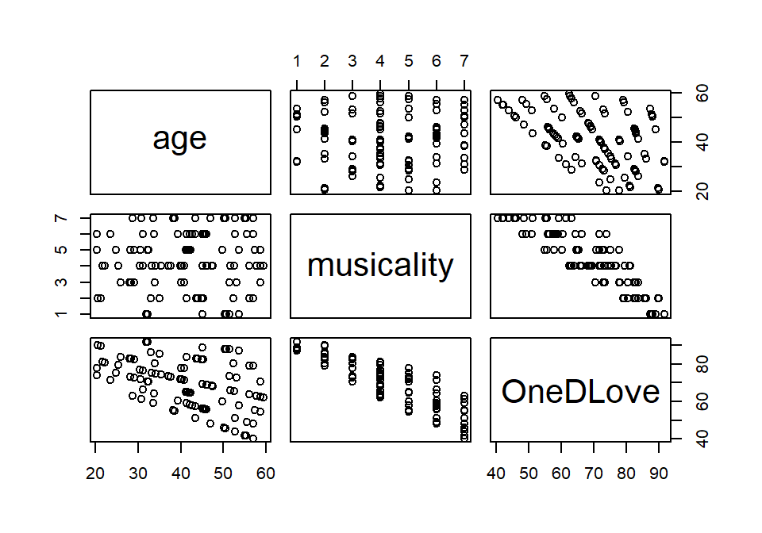

```r
plot(my.data[, c('age', 'musicality', 'OneDLove')])
```

**Task 9:** Does everything look relatively plausible? If not, you could start again at Task 4 (or earlier), changing values or the formula to create `OneDLove` until you’re happy with the result.

**Task 10:** The `OneDLove` data you’ve created above is of *fitted values*, but real data is *noisy* - even when the relationship is extremely strong the real values will not lie perfectly on the ‘line of best fit’. So, add some noise to `OneDLove`! Remember that the noise will have to be normally distributed to match the assumptions of a linear model. Refer back to the formalisations of the linear models in the lecture slides. The noise you are adding corresponds to the error term in the model formalisation - **$\epsilon_i$**. You might want to experiment with the size (sd) of the noise a little…

*Tip:* R makes it really easy to add a value to every element of a vector. To add 5 to every element of vector `x` you can execute `x + 5`. Combine this with the fact that the noise you are adding needs to be normally distributed.

```r
# it should be fairly easy to do this, although obviously the sd of the noise depends on
# the scale of the outcome variable
my.data$OneDLove <- my.data$OneDLove + rnorm(100, 0, 5)
```

**Task 11:** Run a linear regression to test how `age`, `musicality`, and their interaction predict `OneDLove`. Examine your model. How close are the coefficients to the $b$ values that you initially entered into the equation?

```r
model <- lm(OneDLove ~ age * musicality, data = my.data)
summary(model)

Call:
lm(formula = OneDLove ~ age * musicality, data = my.data)

Residuals:
     Min       1Q   Median       3Q      Max
-15.3711  -3.9560   0.1318   3.6967  10.4237

Coefficients:
                Estimate Std. Error t value Pr(>|t|)
(Intercept)    115.48799    6.12180  18.865  < 2e-16 ***
age             -0.39116    0.13903  -2.814 0.005944 **
musicality      -5.00602    1.35215  -3.702 0.000357 ***
age:musicality  -0.04451    0.03052  -1.459 0.147920
---
Signif. codes:  0 '***' 0.001 '**' 0.01 '*' 0.05 '.' 0.1 ' ' 1

Residual standard error: 5.428 on 96 degrees of freedom
Multiple R-squared:  0.872, Adjusted R-squared:  0.868
F-statistic:   218 on 3 and 96 DF,  p-value: < 2.2e-16
```

**Task 12:** Check the model assumptions. Are the residuals normal? Do the other diagnostics look sensible?

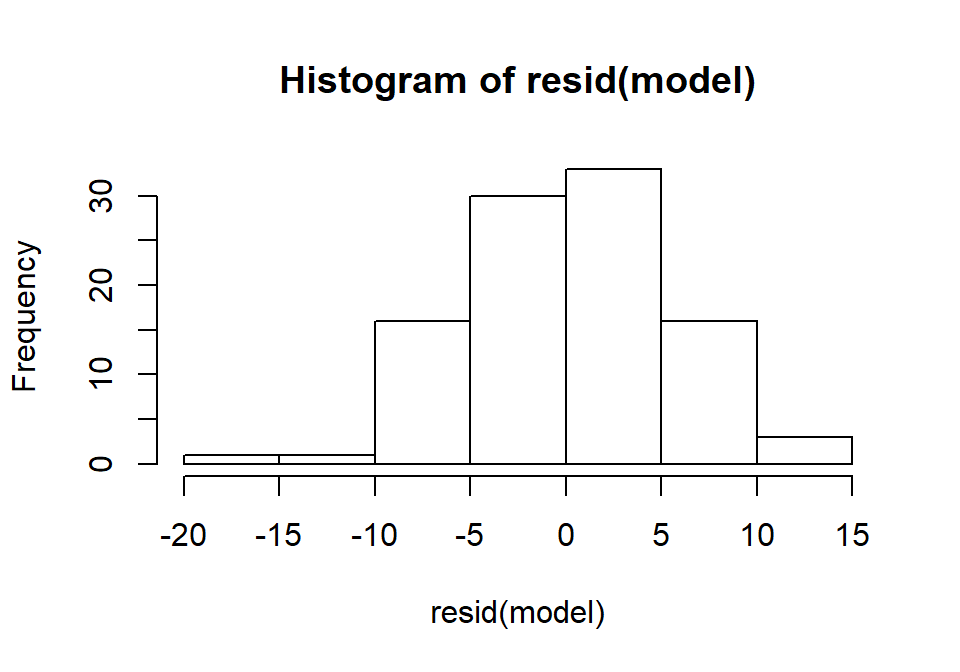

```r
hist(resid(model))
```

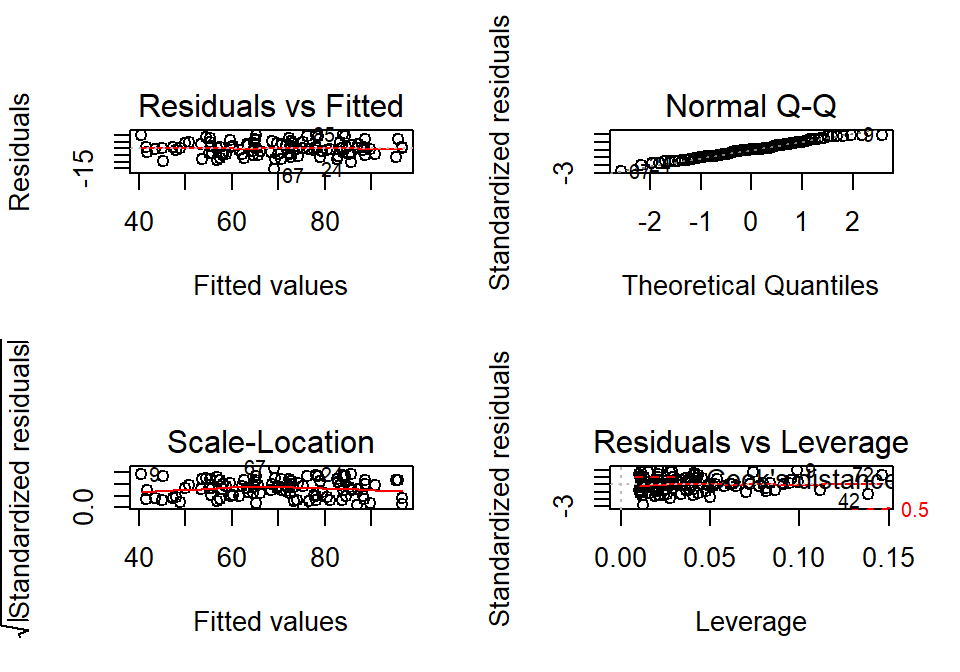

```r
par(mfrow = c(2, 2)) # to plot all of the below in one window
plot(model)
```

```r
par(mfrow = c(1, 1)) # revert back to one plot per window
```

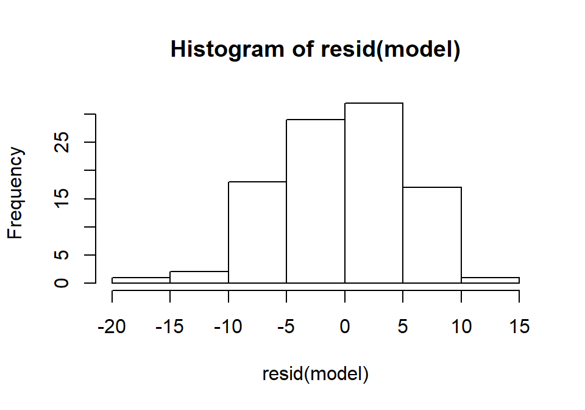

```r
## obviously you could choose almost anything here; I've chosen the f distribution
## because I know it's skewed
my.data$OneDLove <- my.data$OneDLove + rf(100, 1, 50)
model <- lm(OneDLove ~ age * musicality, data = my.data)
summary(model)

Call:
lm(formula = OneDLove ~ age * musicality, data = my.data)

Residuals:
     Min       1Q   Median       3Q      Max
-16.2338  -4.3042   0.0293   4.1065  12.5244

Coefficients:
                Estimate Std. Error t value Pr(>|t|)
(Intercept)    118.11228    6.33343  18.649  < 2e-16 ***
age             -0.42987    0.14383  -2.989 0.003558 **
musicality      -5.48169    1.39889  -3.919 0.000167 ***
age:musicality  -0.03404    0.03157  -1.078 0.283675
---
Signif. codes:  0 '***' 0.001 '**' 0.01 '*' 0.05 '.' 0.1 ' ' 1

Residual standard error: 5.615 on 96 degrees of freedom
Multiple R-squared:  0.8642,    Adjusted R-squared:   0.86
F-statistic: 203.6 on 3 and 96 DF,  p-value: < 2.2e-16
hist(resid(model))
```

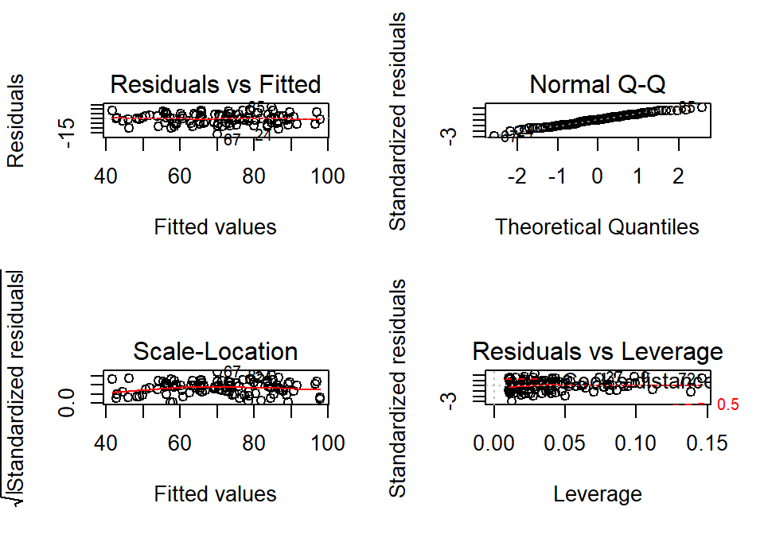

```r
par(mfrow = c(2, 2))
plot(model)
```

```r
par(mfrow = c(1, 1))
### etc.
```

If you selected a continuous measure of musicality you were working with a *continuous*$\times$*continuous* interaction. A good way to visualise this is to ‘bin’ the data based on one of the explanatory variables. In the example above we might create a grouped age variable that split age into 4 or 5 equal sized categories (we used `cut()` in an earlier lab to achieve this). Then create plots of musicality by age for each of these groups separately (or you could put them in one plot and use a method to identify which points belong to which group, it’s up to you). A significant interaction in our models suggests that the pattern across each group should not be identical, there should be some deviation.

**Task 14:** *If you have time*: Create these plots for your data to visualise any significant interaction.

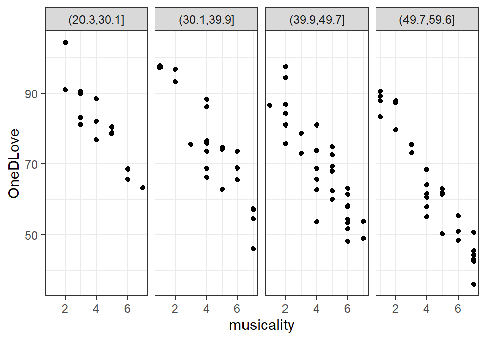

```r
# A few different examples of illustrating this:

my.data$cutAge <- cut(my.data$age, 4)

#a ggplot
library(ggplot2)
inter.plot <- ggplot(data = my.data,
       aes(x = musicality, y = OneDLove))
inter.plot + geom_point() + theme_bw() + facet_grid(. ~ cutAge)
```

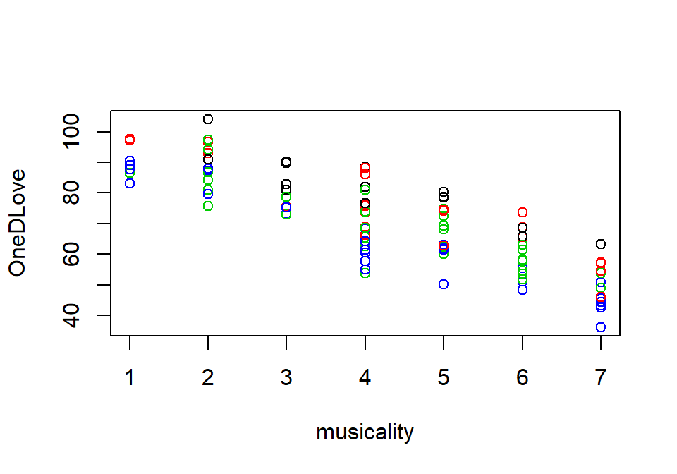

```r
#plot() colouring by age bin
with(my.data, plot(musicality, OneDLove, col = cutAge))
```

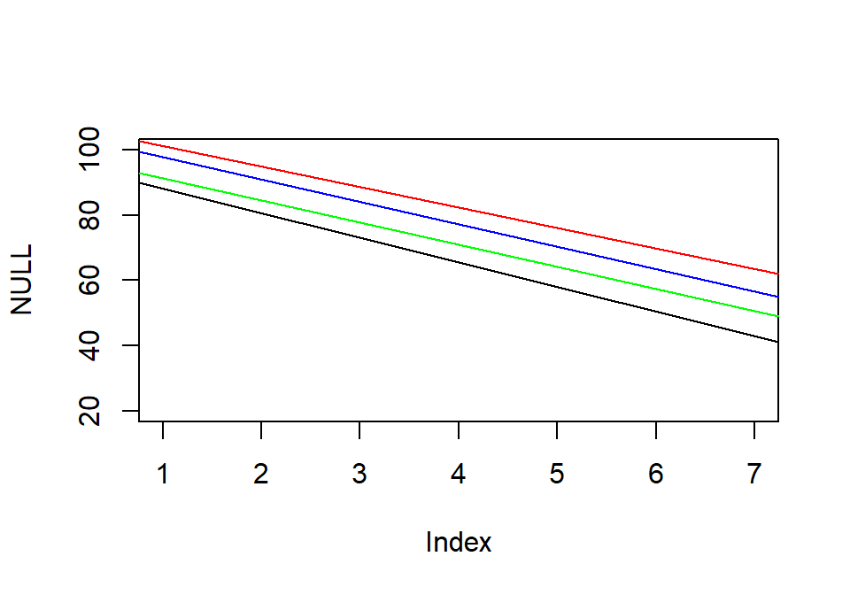

```r
#alternatively, plot each fitted line using abline()
#Note: repeat command, changing the subset variable and col on each
plot(NULL, xlim = c(1, 7), ylim = c(20, 100))
abline(lm(OneDLove ~ musicality,
          data = subset(my.data, cutAge == levels(cutAge)[1])), col = "red")
abline(lm(OneDLove ~ musicality,
          data = subset(my.data, cutAge == levels(cutAge)[2])), col = "blue")
abline(lm(OneDLove ~ musicality,
          data = subset(my.data, cutAge == levels(cutAge)[3])), col = "green")
abline(lm(OneDLove ~ musicality,
          data = subset(my.data, cutAge == levels(cutAge)[4])), col = "black")
```

**Task 15:** *If you have time*: Start again at Task 4. This time create a variable called `PFLove` (for ‘Pink Floyd Love’) which is based on `age` and `gender`. (*N.B.,* you may need to make a column called `is.male`, like similar columns in the lecture, to help with this (use the `ifelse()`) function.) Run through the steps above again, checking that you can retrieve your $b$ values from the regression you finally run.

```r
### something like:
my.data$is.male <- ifelse(my.data$gender == 'M', 1, 0)
my.data$PFLove <- with(my.data, 30 + 5 * is.male + .4 * age + .3 * age * is.male)
my.data$PFLove <- my.data$PFLove + rnorm(100, 0, 5)
```

```r
# look at data
with(my.data, plot_ly(x = ~age, y = ~is.male, z = ~PFLove))
```

```r
# we can take advantage of automatic contrast coding in R
model <- lm(PFLove ~ age * gender, data = my.data)
summary(model)

Call:
lm(formula = PFLove ~ age * gender, data = my.data)

Residuals:
     Min       1Q   Median       3Q      Max
-12.4139  -3.7886   0.3552   2.8661  13.5448

Coefficients:
            Estimate Std. Error t value Pr(>|t|)
(Intercept) 24.18625    2.93583   8.238 8.87e-13 ***
age          0.56611    0.06878   8.231 9.21e-13 ***
genderM      8.03265    4.16934   1.927   0.0570 .
age:genderM  0.19601    0.09714   2.018   0.0464 *
---
Signif. codes:  0 '***' 0.001 '**' 0.01 '*' 0.05 '.' 0.1 ' ' 1

Residual standard error: 5.193 on 96 degrees of freedom
Multiple R-squared:  0.8221,    Adjusted R-squared:  0.8165
F-statistic: 147.9 on 3 and 96 DF,  p-value: < 2.2e-16
```

[^1]: If the plot disappears after a split-second, just click inside the RStudio plotting window and it should pop back up.